# Part I - Prosper loans dataset exploration

## Introduction

> The dataset we will investigate in this project were taken from Prosper bank which is America’s first marketplace lending platform, with over 9 billion dollar in funded loans. This data set contains 113,937 loans with 81 variables on each loan, including loan amount, borrower rate (or interest rate), current loan status, borrower income, borrower employment status, borrower credit history, and the latest payment information.

## Preliminary Wrangling

```python
# import all packages and set plots to be embedded inline
import numpy as np
import pandas as pd
import matplotlib.pyplot as plt
import seaborn as sns

%matplotlib inline
```

```python
df = pd.read_csv('prosperLoanData.csv')
```

```python
df.head()
```

|  | ListingKey | ListingNumber | ListingCreationDate | CreditGrade | Term | LoanStatus | ClosedDate | BorrowerAPR | BorrowerRate | LenderYield | ... | LP_ServiceFees | LP_CollectionFees | LP_GrossPrincipalLoss | LP_NetPrincipalLoss | LP_NonPrincipalRecoverypayments | PercentFunded | Recommendations | InvestmentFromFriendsCount | InvestmentFromFriendsAmount | Investors |
| --- | --- | --- | --- | --- | --- | --- | --- | --- | --- | --- | --- | --- | --- | --- | --- | --- | --- | --- | --- | --- | --- |
| 0 | 1021339766868145413AB3B | 193129 | 2007-08-26 19:09:29.263000000 | C | 36 | Completed | 2009-08-14 00:00:00 | 0.16516 | 0.1580 | 0.1380 | ... | -133.18 | 0.0 | 0.0 | 0.0 | 0.0 | 1.0 | 0 | 0 | 0.0 | 258 |
| 1 | 10273602499503308B223C1 | 1209647 | 2014-02-27 08:28:07.900000000 | NaN | 36 | Current | NaN | 0.12016 | 0.0920 | 0.0820 | ... | 0.00 | 0.0 | 0.0 | 0.0 | 0.0 | 1.0 | 0 | 0 | 0.0 | 1 |
| 2 | 0EE9337825851032864889A | 81716 | 2007-01-05 15:00:47.090000000 | HR | 36 | Completed | 2009-12-17 00:00:00 | 0.28269 | 0.2750 | 0.2400 | ... | -24.20 | 0.0 | 0.0 | 0.0 | 0.0 | 1.0 | 0 | 0 | 0.0 | 41 |
| 3 | 0EF5356002482715299901A | 658116 | 2012-10-22 11:02:35.010000000 | NaN | 36 | Current | NaN | 0.12528 | 0.0974 | 0.0874 | ... | -108.01 | 0.0 | 0.0 | 0.0 | 0.0 | 1.0 | 0 | 0 | 0.0 | 158 |
| 4 | 0F023589499656230C5E3E2 | 909464 | 2013-09-14 18:38:39.097000000 | NaN | 36 | Current | NaN | 0.24614 | 0.2085 | 0.1985 | ... | -60.27 | 0.0 | 0.0 | 0.0 | 0.0 | 1.0 | 0 | 0 | 0.0 | 20 |

5 rows × 81 columns

```python
df.info()
```

```
<class 'pandas.core.frame.DataFrame'>
RangeIndex: 113937 entries, 0 to 113936
Data columns (total 81 columns):
 #   Column                               Non-Null Count   Dtype
---  ------                               --------------   -----
 0   ListingKey                           113937 non-null  object
 1   ListingNumber                        113937 non-null  int64
 2   ListingCreationDate                  113937 non-null  object
 3   CreditGrade                          28953 non-null   object
 4   Term                                 113937 non-null  int64
 5   LoanStatus                           113937 non-null  object
 6   ClosedDate                           55089 non-null   object
 7   BorrowerAPR                          113912 non-null  float64
 8   BorrowerRate                         113937 non-null  float64
 9   LenderYield                          113937 non-null  float64
```

[output cut: 73 more lines]

```python
print(df.shape)
df.dtypes
```

```
(113937, 81)
```

```
ListingKey                      object
ListingNumber                    int64
ListingCreationDate             object
CreditGrade                     object
Term                             int64
                                ...
PercentFunded                  float64
Recommendations                  int64
InvestmentFromFriendsCount       int64
InvestmentFromFriendsAmount    float64
Investors                        int64
Length: 81, dtype: object
```

```python
df.columns
```

```
Index(['ListingKey', 'ListingNumber', 'ListingCreationDate', 'CreditGrade',
       'Term', 'LoanStatus', 'ClosedDate', 'BorrowerAPR', 'BorrowerRate',
       'LenderYield', 'EstimatedEffectiveYield', 'EstimatedLoss',
       'EstimatedReturn', 'ProsperRating (numeric)', 'ProsperRating (Alpha)',
       'ProsperScore', 'ListingCategory (numeric)', 'BorrowerState',
       'Occupation', 'EmploymentStatus', 'EmploymentStatusDuration',
       'IsBorrowerHomeowner', 'CurrentlyInGroup', 'GroupKey',
       'DateCreditPulled', 'CreditScoreRangeLower', 'CreditScoreRangeUpper',
       'FirstRecordedCreditLine', 'CurrentCreditLines', 'OpenCreditLines',
       'TotalCreditLinespast7years', 'OpenRevolvingAccounts',
       'OpenRevolvingMonthlyPayment', 'InquiriesLast6Months', 'TotalInquiries',
       'CurrentDelinquencies', 'AmountDelinquent', 'DelinquenciesLast7Years',
       'PublicRecordsLast10Years', 'PublicRecordsLast12Months',
       'RevolvingCreditBalance', 'BankcardUtilization',
       'AvailableBankcardCredit', 'TotalTrades',
       'TradesNeverDelinquent (percentage)', 'TradesOpenedLast6Months',
       'DebtToIncomeRatio', 'IncomeRange', 'IncomeVerifiable',
       'StatedMonthlyIncome', 'LoanKey', 'TotalProsperLoans',
       'TotalProsperPaymentsBilled', 'OnTimeProsperPayments',
       'ProsperPaymentsLessThanOneMonthLate',
       'ProsperPaymentsOneMonthPlusLate', 'ProsperPrincipalBorrowed',
       'ProsperPrincipalOutstanding', 'ScorexChangeAtTimeOfListing',
       'LoanCurrentDaysDelinquent', 'LoanFirstDefaultedCycleNumber',
       'LoanMonthsSinceOrigination', 'LoanNumber', 'LoanOriginalAmount',
       'LoanOriginationDate', 'LoanOriginationQuarter', 'MemberKey',
       'MonthlyLoanPayment', 'LP_CustomerPayments',
       'LP_CustomerPrincipalPayments', 'LP_InterestandFees', 'LP_ServiceFees',
       'LP_CollectionFees', 'LP_GrossPrincipalLoss', 'LP_NetPrincipalLoss',
       'LP_NonPrincipalRecoverypayments', 'PercentFunded', 'Recommendations',
       'InvestmentFromFriendsCount', 'InvestmentFromFriendsAmount',
       'Investors'],
      dtype='object')
```

## Data cleaning

```python
#Extracting dates from ListingCreationDate column
df['year'] = df.ListingCreationDate.apply(lambda x: x.split("-")[0]).astype(str)
df['month'] = df.ListingCreationDate.apply(lambda x: x.split("-")[1]).astype(str)
```

```python
#Creating a subset dataframe for the features we want to focus on
df2 = df[['ListingNumber','year','month','Term','Occupation', 'LoanStatus', 'ListingCategory (numeric)' , 'ProsperRating (Alpha)' , 'EmploymentStatus' , 'EmploymentStatusDuration', 'IncomeRange' ,'StatedMonthlyIncome' ,'MonthlyLoanPayment' ]]
```

```python
df2.sample(5)
```

|  | ListingNumber | year | month | Term | Occupation | LoanStatus | ListingCategory (numeric) | ProsperRating (Alpha) | EmploymentStatus | EmploymentStatusDuration | IncomeRange | StatedMonthlyIncome | MonthlyLoanPayment |
| --- | --- | --- | --- | --- | --- | --- | --- | --- | --- | --- | --- | --- | --- |
| 103660 | 569012 | 2012 | 03 | 36 | Sales - Retail | Current | 7 | HR | Employed | 41.0 | $1-24,999 | 1750.000000 | 173.71 |
| 64671 | 1092840 | 2013 | 12 | 36 | Other | Current | 1 | E | Employed | 178.0 | $50,000-74,999 | 4598.500000 | 166.54 |
| 54169 | 931137 | 2013 | 09 | 36 | Nurse (RN) | Current | 1 | B | Employed | 296.0 | $100,000+ | 8333.333333 | 523.66 |
| 58543 | 289139 | 2008 | 03 | 36 | Other | Chargedoff | 1 | NaN | Full-time | 7.0 | $25,000-49,999 | 2083.333333 | 402.60 |
| 11951 | 610265 | 2012 | 07 | 36 | Other | Completed | 2 | A | Employed | 294.0 | $100,000+ | 12916.666667 | 424.93 |

```python
#Renaming cols
df2 = df2.rename(columns = {'ListingCategory (numeric)': 'ListingCategory'})
df2 = df2.rename(columns = {'ProsperRating (Alpha)': 'ProsperRating'})
```

```python
df2.columns
```

```
Index(['ListingNumber', 'year', 'month', 'Term', 'Occupation', 'LoanStatus',
       'ListingCategory', 'ProsperRating', 'EmploymentStatus',
       'EmploymentStatusDuration', 'IncomeRange', 'StatedMonthlyIncome',
       'MonthlyLoanPayment'],
      dtype='object')
```

```python
df2.shape
```

```
(113937, 13)
```

```python
df2.duplicated().sum()
```

```
871
```

```python
df2.drop_duplicates(inplace=True)
```

```python
df2.duplicated().sum()
```

```
0
```

```python
df.describe()
```

|  | ListingNumber | Term | BorrowerAPR | BorrowerRate | LenderYield | EstimatedEffectiveYield | EstimatedLoss | EstimatedReturn | ProsperRating (numeric) | ProsperScore | ... | LP_ServiceFees | LP_CollectionFees | LP_GrossPrincipalLoss | LP_NetPrincipalLoss | LP_NonPrincipalRecoverypayments | PercentFunded | Recommendations | InvestmentFromFriendsCount | InvestmentFromFriendsAmount | Investors |
| --- | --- | --- | --- | --- | --- | --- | --- | --- | --- | --- | --- | --- | --- | --- | --- | --- | --- | --- | --- | --- | --- |
| count | 1.139370e+05 | 113937.000000 | 113912.000000 | 113937.000000 | 113937.000000 | 84853.000000 | 84853.000000 | 84853.000000 | 84853.000000 | 84853.000000 | ... | 113937.000000 | 113937.000000 | 113937.000000 | 113937.000000 | 113937.000000 | 113937.000000 | 113937.000000 | 113937.000000 | 113937.000000 | 113937.000000 |
| mean | 6.278857e+05 | 40.830248 | 0.218828 | 0.192764 | 0.182701 | 0.168661 | 0.080306 | 0.096068 | 4.072243 | 5.950067 | ... | -54.725641 | -14.242698 | 700.446342 | 681.420499 | 25.142686 | 0.998584 | 0.048027 | 0.023460 | 16.550751 | 80.475228 |
| std | 3.280762e+05 | 10.436212 | 0.080364 | 0.074818 | 0.074516 | 0.068467 | 0.046764 | 0.030403 | 1.673227 | 2.376501 | ... | 60.675425 | 109.232758 | 2388.513831 | 2357.167068 | 275.657937 | 0.017919 | 0.332353 | 0.232412 | 294.545422 | 103.239020 |
| min | 4.000000e+00 | 12.000000 | 0.006530 | 0.000000 | -0.010000 | -0.182700 | 0.004900 | -0.182700 | 1.000000 | 1.000000 | ... | -664.870000 | -9274.750000 | -94.200000 | -954.550000 | 0.000000 | 0.700000 | 0.000000 | 0.000000 | 0.000000 | 1.000000 |
| 25% | 4.009190e+05 | 36.000000 | 0.156290 | 0.134000 | 0.124200 | 0.115670 | 0.042400 | 0.074080 | 3.000000 | 4.000000 | ... | -73.180000 | 0.000000 | 0.000000 | 0.000000 | 0.000000 | 1.000000 | 0.000000 | 0.000000 | 0.000000 | 2.000000 |
| 50% | 6.005540e+05 | 36.000000 | 0.209760 | 0.184000 | 0.173000 | 0.161500 | 0.072400 | 0.091700 | 4.000000 | 6.000000 | ... | -34.440000 | 0.000000 | 0.000000 | 0.000000 | 0.000000 | 1.000000 | 0.000000 | 0.000000 | 0.000000 | 44.000000 |
| 75% | 8.926340e+05 | 36.000000 | 0.283810 | 0.250000 | 0.240000 | 0.224300 | 0.112000 | 0.116600 | 5.000000 | 8.000000 | ... | -13.920000 | 0.000000 | 0.000000 | 0.000000 | 0.000000 | 1.000000 | 0.000000 | 0.000000 | 0.000000 | 115.000000 |
| max | 1.255725e+06 | 60.000000 | 0.512290 | 0.497500 | 0.492500 | 0.319900 | 0.366000 | 0.283700 | 7.000000 | 11.000000 | ... | 32.060000 | 0.000000 | 25000.000000 | 25000.000000 | 21117.900000 | 1.012500 | 39.000000 | 33.000000 | 25000.000000 | 1189.000000 |

8 rows × 61 columns

```python
df2.describe()
```

|  | ListingNumber | Term | ListingCategory | EmploymentStatusDuration | StatedMonthlyIncome | MonthlyLoanPayment |
| --- | --- | --- | --- | --- | --- | --- |
| count | 1.130660e+05 | 113066.000000 | 113066.000000 | 105441.000000 | 1.130660e+05 | 113066.000000 |
| mean | 6.248036e+05 | 40.800170 | 2.776838 | 96.060584 | 5.605120e+03 | 271.932742 |
| std | 3.273262e+05 | 10.421518 | 3.998188 | 94.432241 | 7.495596e+03 | 192.549979 |
| min | 4.000000e+00 | 12.000000 | 0.000000 | 0.000000 | 0.000000e+00 | 0.000000 |
| 25% | 3.976670e+05 | 36.000000 | 1.000000 | 26.000000 | 3.199396e+03 | 130.950000 |
| 50% | 5.978385e+05 | 36.000000 | 1.000000 | 67.000000 | 4.666667e+03 | 217.370000 |
| 75% | 8.849650e+05 | 36.000000 | 3.000000 | 137.000000 | 6.824688e+03 | 370.570000 |
| max | 1.255725e+06 | 60.000000 | 20.000000 | 755.000000 | 1.750003e+06 | 2251.510000 |

```python
df2.head()
```

|  | ListingNumber | year | month | Term | Occupation | LoanStatus | ListingCategory | ProsperRating | EmploymentStatus | EmploymentStatusDuration | IncomeRange | StatedMonthlyIncome | MonthlyLoanPayment |
| --- | --- | --- | --- | --- | --- | --- | --- | --- | --- | --- | --- | --- | --- |
| 0 | 193129 | 2007 | 08 | 36 | Other | Completed | 0 | NaN | Self-employed | 2.0 | $25,000-49,999 | 3083.333333 | 330.43 |
| 1 | 1209647 | 2014 | 02 | 36 | Professional | Current | 2 | A | Employed | 44.0 | $50,000-74,999 | 6125.000000 | 318.93 |
| 2 | 81716 | 2007 | 01 | 36 | Other | Completed | 0 | NaN | Not available | NaN | Not displayed | 2083.333333 | 123.32 |
| 3 | 658116 | 2012 | 10 | 36 | Skilled Labor | Current | 16 | A | Employed | 113.0 | $25,000-49,999 | 2875.000000 | 321.45 |
| 4 | 909464 | 2013 | 09 | 36 | Executive | Current | 2 | D | Employed | 44.0 | $100,000+ | 9583.333333 | 563.97 |

### What is/are the main feature(s) of interest in your dataset?

> I'm intrested in the reason why people might take loans, what they do for living and, the average income of those people.

### What features in the dataset do you think will help support your investigation into your feature(s) of interest?

- ListingNumber
- year
- month
- Term
- Occupation
- LoanStatus
- ListingCategory
- ProsperRating(Alpha)
- EmploymentStatus
- EmploymentStatusDuration
- IncomeRange
- StatedMonthlyIncome
- MonthlyLoanPayment

## Univariate Exploration

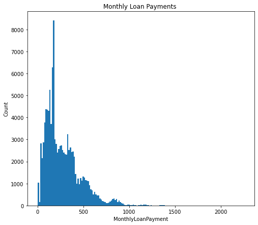

```python
# Plotting the main variable of interest BorrowerAPR
binsize = 14
bins = np.arange(0, df2['MonthlyLoanPayment'].max()+binsize, binsize)
#print(bins)
plt.figure(figsize=[8, 7])
plt.hist(data = df2, x = 'MonthlyLoanPayment', bins=bins)
plt.xlabel('MonthlyLoanPayment')
plt.ylabel('Count')
plt.title("Monthly Loan Payments ")
plt.show()
```

```python
df2['MonthlyLoanPayment'].mean()
```

[output not shown]

```
Prosper loan ratings
AA     5324
HR     6909
E      9713
D     14169
A     14389
B     15368
C     18093
Name: ProsperRating, dtype: int64
```

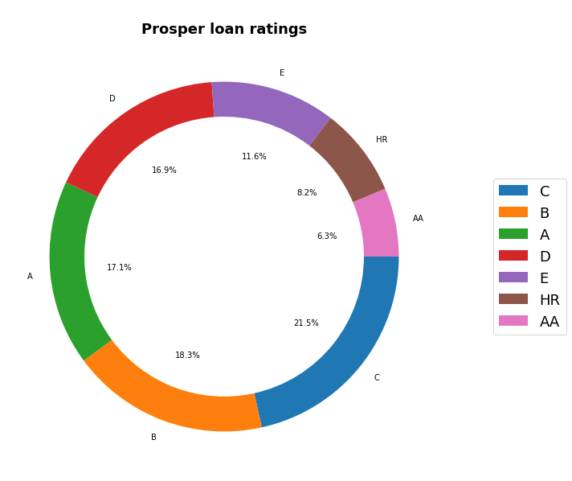

```python
LJobs = df2['ProsperRating'].value_counts()
print('Prosper loan ratings')
print(LJobs.sort_values())
plt.figure(figsize=(10,10))
plt.pie(LJobs,
        labels = LJobs.index,
        counterclock = False,
        autopct = '%1.1f%%',
        wedgeprops = {'width' : 0.2})
plt.legend(loc="center right", bbox_to_anchor=(1.3,0.5) ,fontsize=18)
plt.title('\nProsper loan ratings',
          fontsize = 18,
          fontweight = 'bold')
```

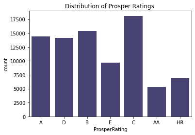

```python
plt.title("Distribution of Prosper Ratings ")
sns.countplot(data=df2, x='ProsperRating',color=vb);
```

#### The rating customer ratings are AA, A, B, C, D, E, HR , where AA is the safest rating given for a borrower and HR is the highest in term of risks.

```python
sns.color_palette('mako')
```

```python
blue = sns.color_palette('seismic')[:1]
ddb , vb, blu, lblu , llb , gb  =  sns.color_palette('mako')[:6]
```

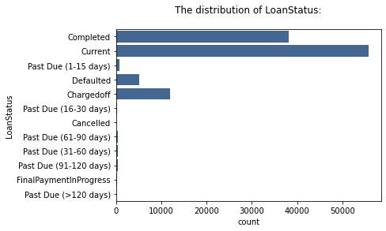

```python
#Create a function to save time exploring bar charts
def barplt(df2, col , clr):
  # plot
  ax =  sns.countplot(data=df2, y= col, color = clr   );
  # Add title and format it
  ax.set_title("The distribution of {}:\n".format(col))

  # display dataframe
  display(ax)

# call function
barplt(df2,'LoanStatus',blu )
```

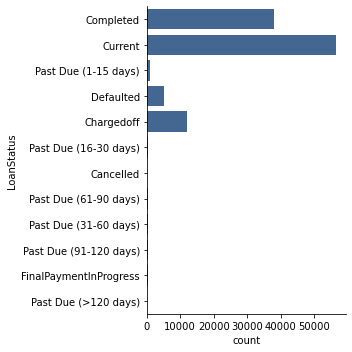

```python
sns.catplot(data=df, y="LoanStatus", kind="count", color = blu)
```

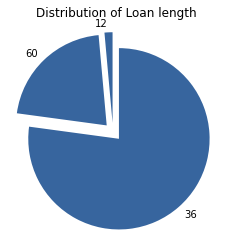

```python
#Plot of Long Duration using the Term attribute
base_color = sns.color_palette()[0]
colors = [ blu ,blu,blu]
explode = (0.1, 0.1, 0.1)
sorted_counts = df2['Term'].value_counts()
plt.pie(sorted_counts,explode=explode, labels = sorted_counts.index, startangle = 90, counterclock = False,colors=colors);
plt.axis('square')
plt.title("Distribution of Loan length");
```

```python
LS.sort_values( ascending = True)
x = df2.groupby('LoanStatus').count()
x
```

[output not shown]

```python
IncomeOrder = df2['IncomeRange'].value_counts().index
```

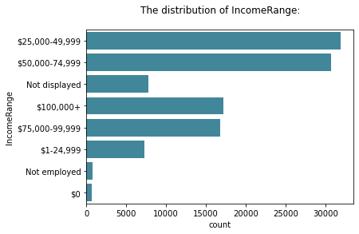

```python
barplt(df2,'IncomeRange',lblu )
```

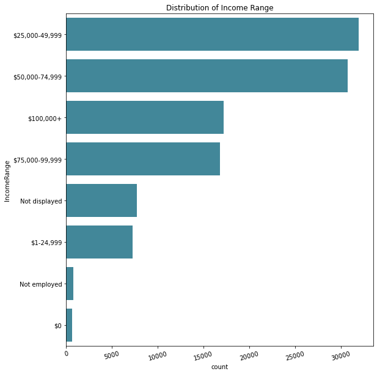

```python
plt.figure(figsize=[9, 10])
plt.title("Distribution of Income Range")
sns.countplot(data=df2, y='IncomeRange', color = lblu , order= IncomeOrder  );

plt.xticks(rotation=15);
```

```python
#OC = df2.value_counts(['Occupation']).head(10)
OC = df2['Occupation'].value_counts().head(10).index
df2['Occupation'].value_counts().head(10)
```

```
Other                       28422
Professional                13531
Computer Programmer          4442
Executive                    4280
Teacher                      3729
Administrative Assistant     3677
Analyst                      3578
Sales - Commission           3414
Accountant/CPA               3209
Clerical                     3135
Name: Occupation, dtype: int64
```

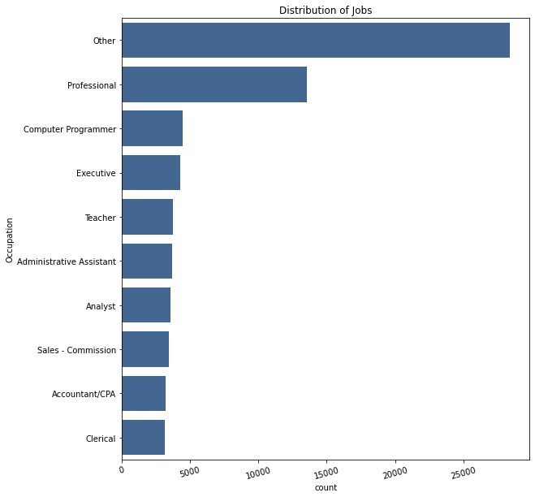

```python
plt.figure(figsize=[9, 10])
plt.title("Distribution of Jobs")
sns.countplot(data=df2, y= 'Occupation', color = blu , order = OC  );
plt.xticks(rotation=15);
```

### Of the features you investigated, were there any unusual distributions? Did you perform any operations on the data to tidy, adjust, or change the form of the data? If so, why did you do this?

- For the occupation, there is the professional group, the term professional might mean a lot of diffrent jobs and I think they should have choosen a more specifec group name.
- Unlike the professional term, the loan status has a lot of details for example: Past due (16-30) , Past due (91-120) , and so on , this overdetailed makes it harder to discover any useful insights.
- For the listing creation date, I have created two new columns 'year' and 'month' derived from 'listing creation date' columns, and we might use it in the upcoming phases of exploration.

## Bivariate Exploration

```python
lb,b,db,vb,v,p = sns.color_palette('cool')[:6]
```

```python
AA = df2[df2.ProsperRating == 'AA']
HR = df2[df2.ProsperRating == 'HR']
```

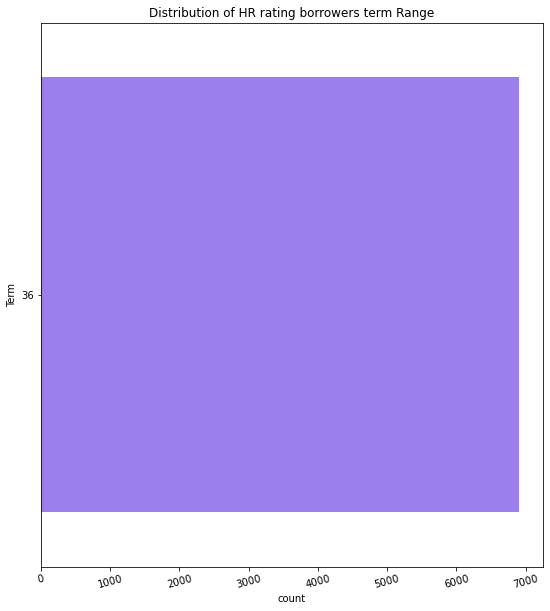

```python
plt.figure(figsize=[9, 10])
plt.title("Distribution of HR rating borrowers term Range")
sns.countplot(data=HR, y= 'Term', color = vb   );
plt.xticks(rotation=15);
```

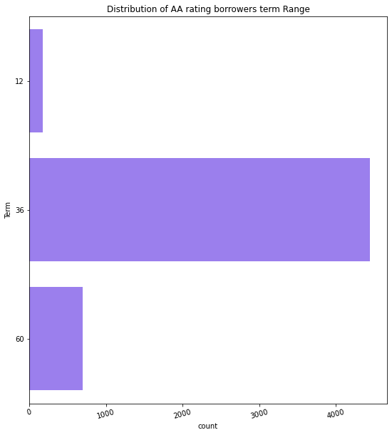

```python
plt.figure(figsize=[9, 10])
plt.title("Distribution of AA rating borrowers term Range")
sns.countplot(data=AA, y= 'Term', color = vb   );
plt.xticks(rotation=15);
```

```python
HRO = df2[df2.ProsperRating == 'HR'].value_counts().head(10).index

HRO
```

[output not shown]

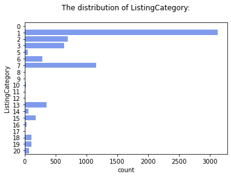

```python
barplt(HR,'ListingCategory',db)
```

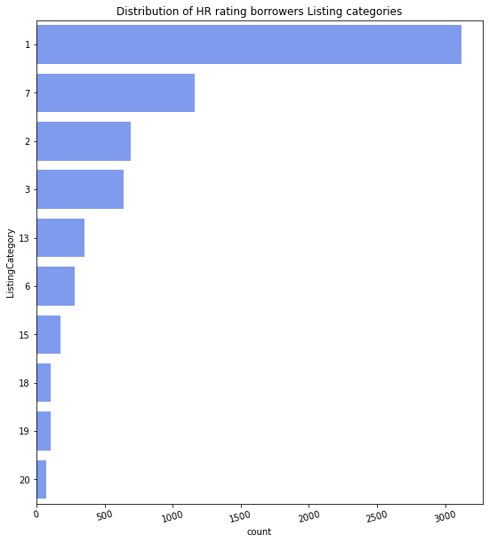

```python
plt.figure(figsize=[9, 10])
plt.title("Distribution of HR rating borrowers Listing categories")
sns.countplot(data=HR, y= 'ListingCategory', color = db , order = [1,7,2,3,13,6,15,18,19,20]   );
plt.xticks(rotation=15);
```

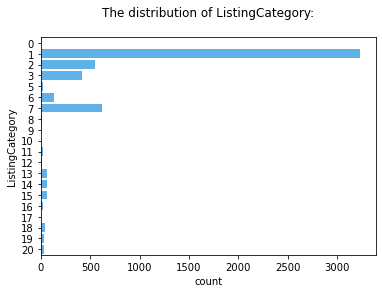

```python
barplt(AA,'ListingCategory',b)
```

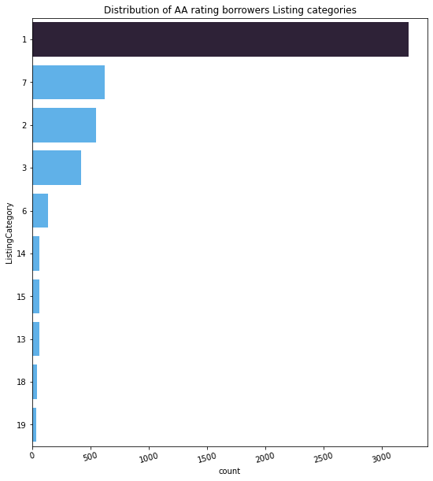

```python
plt.figure(figsize=[9, 10])
pal = [ddb , b , b, b, b, b, b, b,b,b]
plt.title("Distribution of AA rating borrowers Listing categories")
sns.countplot(data=AA, y= 'ListingCategory', palette = pal , order =[1,7,2,3,6,14,15,13,18,19]    );
plt.xticks(rotation=15);
```

1- Debt consolidation 7- Other 2- Home improvment 3- Business 6- Auto 20- Wedding Loans 14- Large purchases 15- Medical / Dental 13- Houshold expenses 18- Taxes 19- Vacations

```python
#Grouping AA and HR ratings by their jobs
AAOC = AA.Occupation.value_counts().index
HROC = HR.Occupation.value_counts().index
```

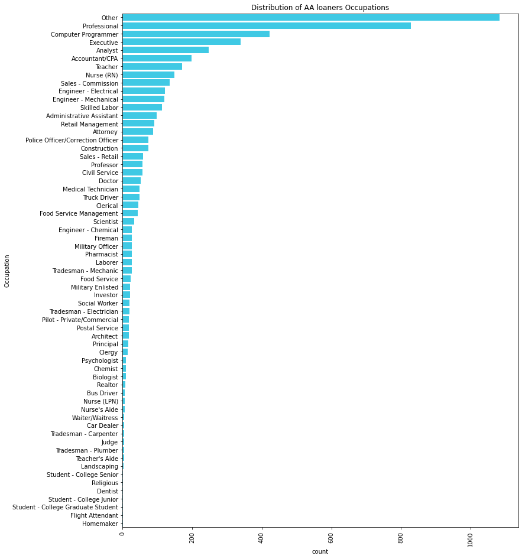

```python
#occupation = previous_borrowers.Occupation.value_counts().index #previous_borrowers.Occupation.unique()
plt.figure(figsize=[12, 16])
sb.countplot(data=AA, y='Occupation', color = lb, order=AAOC);
plt.xticks(rotation=90)
plt.title("Distribution of AA loaners Occupations");
```

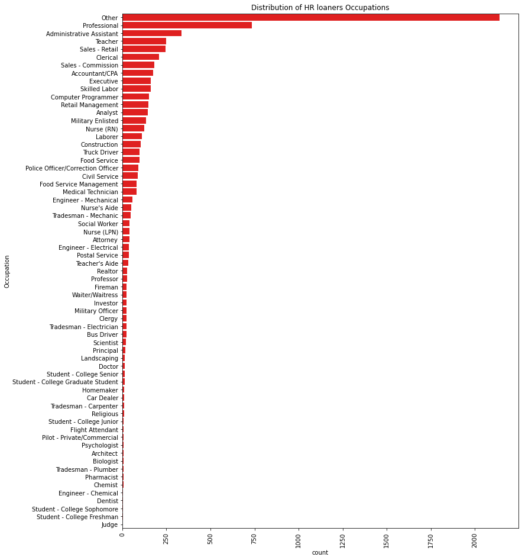

```python
plt.figure(figsize=[12, 16])
sb.countplot(data=HR, y='Occupation', color = 'r', order=HROC);
plt.xticks(rotation=90)
plt.title("Distribution of HR loaners Occupations");
```

```python
IncomeR = df['IncomeRange']
IncomeR
```

```
0         $25,000-49,999
1         $50,000-74,999
2          Not displayed
3         $25,000-49,999
4              $100,000+
               ...
113932    $50,000-74,999
113933    $75,000-99,999
113934    $25,000-49,999
113935    $25,000-49,999
113936    $50,000-74,999
Name: IncomeRange, Length: 113937, dtype: object
```

```python
PlusOneK = df2[df2.IncomeRange == '$100,000+']
PlusOneK
```

[output not shown]

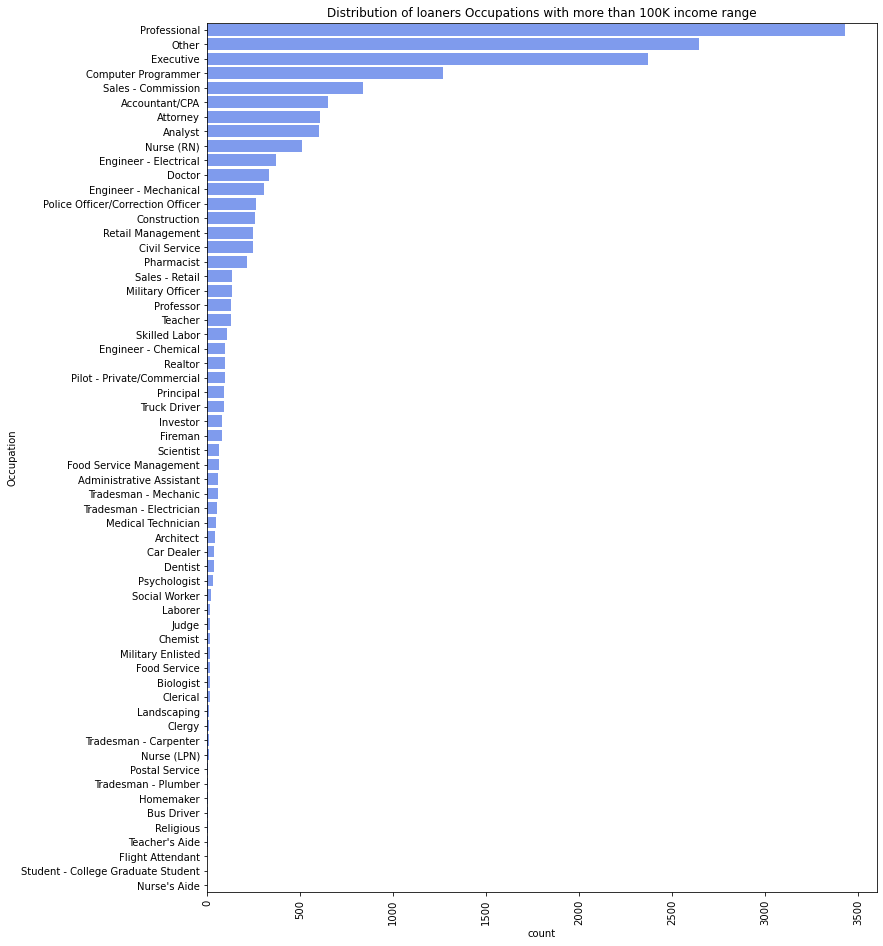

```python
OneKOC = PlusOneK.Occupation.value_counts().index

plt.figure(figsize=[12, 16])
sb.countplot(data=PlusOneK, y='Occupation', color = db, order=OneKOC);
plt.xticks(rotation=90)
plt.title("Distribution of loaners Occupations with more than 100K income range");
```

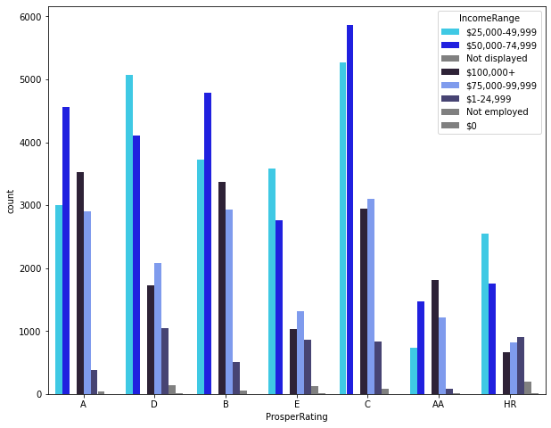

```python
plt.figure(figsize=[10, 8])
pale = [lb,'b','#808080',ddb,db,vb,'#808080','#808080']
sb.countplot(data = df2, x = 'ProsperRating', hue = 'IncomeRange' , palette = pale);
```

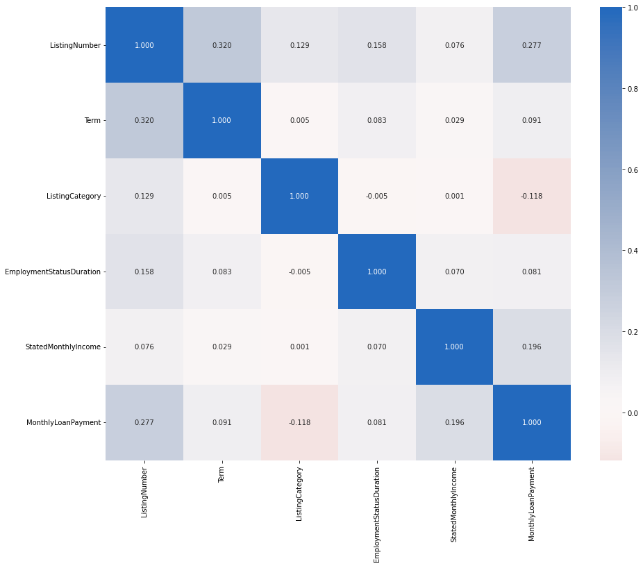

```python
plt.figure(figsize = [15, 12])
sb.heatmap(df2.corr(), annot = True, fmt = '.3f',cmap = 'vlag_r', center = 0);
```

[figure not shown]

```python
sns.heatmap(df2.corr());
```

### Did you observe any interesting relationships between the other features (not the main feature(s) of interest)?

- The highest people in terms of income if we excluded 'Other' and 'Professional' are Excutives then Computer programmers.
- The relationship between Prosper rating and the income range, The highest icome group a person gets, the highest Prosper rating he gets.

## Multivariate Exploration

> Create plots of three or more variables to investigate your data even further. Make sure that your investigations are justified, and follow from your work in the previous sections.

```python
#SortedY = df2['year'].value_counts().index
SortedY = df2.sort_values(by=['year'])
SortedY
```

|  | ListingNumber | year | month | Term | Occupation | LoanStatus | ListingCategory | ProsperRating | EmploymentStatus | EmploymentStatusDuration | IncomeRange | StatedMonthlyIncome | MonthlyLoanPayment |
| --- | --- | --- | --- | --- | --- | --- | --- | --- | --- | --- | --- | --- | --- |
| 29773 | 21 | 2005 | 11 | 36 | NaN | Completed | 0 | NaN | NaN | NaN | Not displayed | 8333.333333 | 91.27 |
| 74114 | 34 | 2005 | 11 | 36 | NaN | Completed | 0 | NaN | NaN | NaN | Not displayed | 9458.333333 | 30.42 |
| 109027 | 40 | 2005 | 11 | 36 | NaN | Completed | 0 | NaN | NaN | NaN | Not displayed | 25000.000000 | 0.00 |
| 25166 | 6 | 2005 | 11 | 36 | NaN | Completed | 0 | NaN | NaN | NaN | Not displayed | 9166.666667 | 29.68 |
| 105925 | 20 | 2005 | 11 | 36 | NaN | Completed | 0 | NaN | NaN | NaN | Not displayed | 6666.666667 | 157.84 |
| ... | ... | ... | ... | ... | ... | ... | ... | ... | ... | ... | ... | ... | ... |
| 103766 | 1169558 | 2014 | 01 | 60 | Computer Programmer | Current | 1 | C | Self-employed | 21.0 | $100,000+ | 10416.666667 | 374.81 |
| 35785 | 1123073 | 2014 | 01 | 36 | Other | Current | 1 | A | Employed | 39.0 | $1-24,999 | 2000.000000 | 115.23 |
| 35784 | 1185274 | 2014 | 02 | 36 | NaN | Current | 1 | A | Other | 1.0 | $1-24,999 | 1800.916667 | 126.72 |
| 10518 | 1179085 | 2014 | 02 | 60 | Analyst | Current | 1 | C | Employed | 34.0 | $100,000+ | 8416.666667 | 367.57 |
| 113936 | 1140093 | 2014 | 01 | 36 | Professor | Current | 1 | A | Employed | 244.0 | $50,000-74,999 | 4583.333333 | 64.90 |

113066 rows × 13 columns

```python
df2 = df2.sort_values(by=['year'])
```

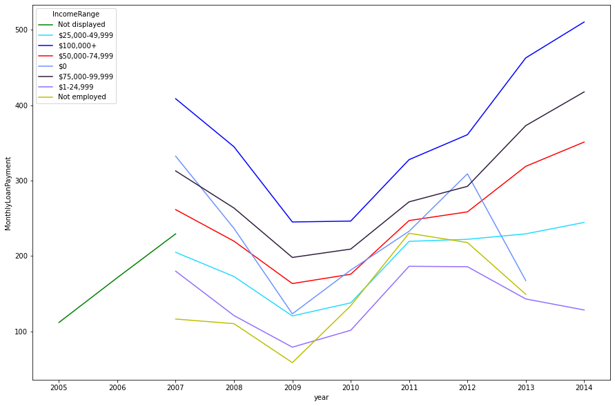

```python
balet = ['g', lb , 'b' , 'r' , db ,ddb ,vb , 'y']

plt.figure(figsize=[15,10])
sns.lineplot(data=df2, x='year', y='MonthlyLoanPayment', hue='IncomeRange', palette = balet , ci = None);
```

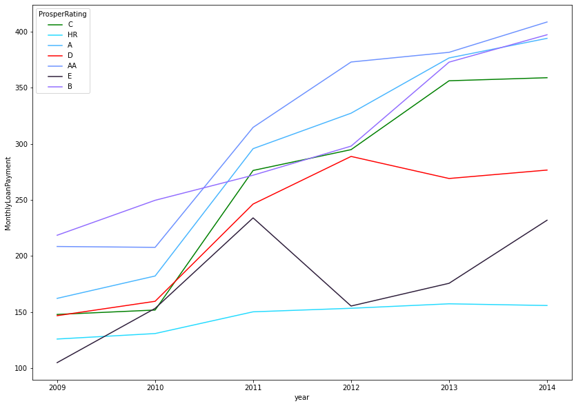

```python
plt.figure(figsize=[14,10])

balet = ['g', lb , b , 'r' , db ,ddb ,vb]
##plotting a lineplot to serve as time series
sns.lineplot(data=df2, x='year', y='MonthlyLoanPayment', hue='ProsperRating', palette = balet , ci = None);
```

```python
#HRO = df2[df2.ProsperRating == 'HR'].value_counts().head(10).index

DebtCons = df2[df2.ListingCategory == 1  ]
StdUse = df2[df2.ListingCategory == 6  ]

DebtCons
```

|  | ListingNumber | year | month | Term | Occupation | LoanStatus | ListingCategory | ProsperRating | EmploymentStatus | EmploymentStatusDuration | IncomeRange | StatedMonthlyIncome | MonthlyLoanPayment |
| --- | --- | --- | --- | --- | --- | --- | --- | --- | --- | --- | --- | --- | --- |
| 44032 | 257634 | 2007 | 12 | 36 | Other | Completed | 1 | NaN | Full-time | 27.0 | $50,000-74,999 | 4333.333333 | 36.28 |
| 71813 | 250641 | 2007 | 12 | 36 | Administrative Assistant | Completed | 1 | NaN | Full-time | 4.0 | $1-24,999 | 1300.000000 | 53.55 |
| 43236 | 254754 | 2007 | 12 | 36 | Professional | Completed | 1 | NaN | Full-time | 75.0 | $100,000+ | 12166.666667 | 833.35 |
| 43327 | 246670 | 2007 | 12 | 36 | Student - College Graduate Student | Completed | 1 | NaN | Part-time | 5.0 | $1-24,999 | 0.083333 | 265.60 |
| 43099 | 252357 | 2007 | 12 | 36 | Realtor | Defaulted | 1 | NaN | Full-time | 46.0 | $100,000+ | 10000.000000 | 810.90 |
| ... | ... | ... | ... | ... | ... | ... | ... | ... | ... | ... | ... | ... | ... |
| 27737 | 1197570 | 2014 | 02 | 60 | Bus Driver | Current | 1 | C | Employed | 49.0 | $100,000+ | 8416.666667 | 206.43 |
| 84371 | 1189940 | 2014 | 02 | 36 | Executive | Current | 1 | B | Employed | 67.0 | $100,000+ | 12500.000000 | 839.22 |
| 111524 | 1145252 | 2014 | 01 | 36 | Other | Current | 1 | B | Employed | 148.0 | $50,000-74,999 | 4750.000000 | 335.69 |
| 27743 | 1221714 | 2014 | 02 | 36 | Analyst | Current | 1 | B | Employed | 174.0 | $50,000-74,999 | 4416.666667 | 203.76 |
| 113936 | 1140093 | 2014 | 01 | 36 | Professor | Current | 1 | A | Employed | 244.0 | $50,000-74,999 | 4583.333333 | 64.90 |

57624 rows × 13 columns

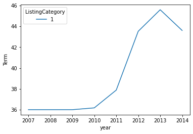

```python
sns.lineplot(data=DebtCons, x='year', y='Term', hue='ListingCategory' , ci = None);
```

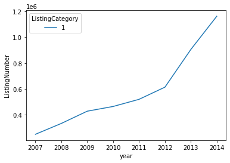

```python
sns.lineplot(data=DebtCons, x='year', y='ListingNumber', hue='ListingCategory' , ci = None);
```

```python
FReq = df2.groupby(['ListingCategory','year'], as_index=False)['ListingNumber'].count()
```

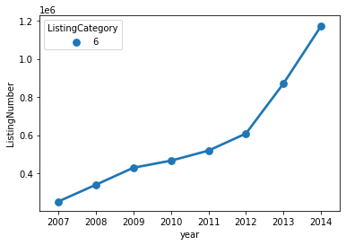

```python
sns.pointplot(data=StdUse, x='year', y='ListingNumber', hue='ListingCategory')
```

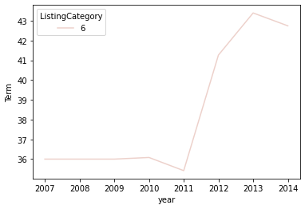

```python
sns.lineplot(data=StdUse, x='year', y='Term', hue='ListingCategory' , ci = None);
```

```python
df2.to_csv('ProsperCleanedData.csv')
```

### Were there any interesting or surprising interactions between features?

- The huge increasing in loans terms from 2011 and going.
- Other than that the features interacted as predicted.

## Conclusions

- My investigation focused on the reason behind why people takes loans, what they do for living and what there income range, in conclusion the main reason why a person might take a loan despite of his job or income was for debt consolidation, and for that the marketing team at Prosper bank should focus on this fact.